# Class_movies_modul_9 (1)

**Name:- Jay Rakeshbhai Patel**  
**Assignment :- Module_9(movies_clustering)**

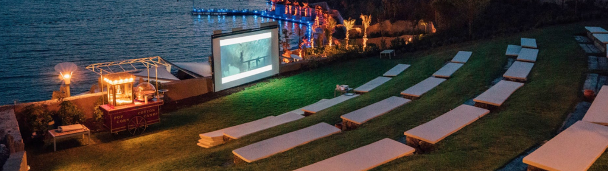

## objective of the purpose

1. The main objective of the this research work to analyze and reprents the various factors that have contributed to the evolutions of movies clustering data over the diffrent types and perform a comparative study between various factors.
2. find the relationship between diffrent type of movies on class students select.
3. find the diffrent type of clustering techniques such as dendogram , K- means,and sklearn.cluster.
4. For this projects Data science Administrations is ours **stakeholders** beacuse for this clustering they analyze students preferences and create new models.

## 2) Data Explorations

In this step we do explore the data using some fuctions. first i import the data file using the read_excel file then after i play with the code use the fuctions of the head and tail to read the data and after that i use the shape fuctions to know the how many rows and columns in data and also us ethe quantile fuctions to know the percentage og the data thenafter use the dtypes,info and describe fuctions to know the mean,max and attribute type and many more.

```python
import numpy as np
import pandas as pd
```

Import the file using the read_excel fuctions.

```python
df_movie = pd.read_excel('Movie_class.xlsx')
```

```python
df_movie
```

|  | Student Name | Using a scale 1 to 10, how much do you like action movies? (use decimals, e.g. 4.2) | Using a scale 1 to 10, how much do you like adventure movies? (use decimals, e.g. 4.2) | Using a scale 1 to 10, how much do you like comedy movies? (use decimals, e.g. 4.2) | Using a scale 1 to 10, how much do you like crime movies? (use decimals, e.g. 4.2) | Using a scale 1 to 10, how much do you like drama movies? | Using a scale 1 to 10, how much do you like fantasy movies? | Using a scale 1 to 10, how much do you like science fiction movies? | Using a scale 1 to 10, how much do you like horror movies? | Using a scale 1 to 10, how much do you like mystery movies? | Using a scale 1 to 10, how much do you like romance movies? | Using a scale 1 to 10, how much do you like thriller movies? | Using a scale 1 to 10, how much do you like documentary movies? | Using a scale 1 to 10, how much do you like animated movies? | On average, how many movies you watch on a single week | Which of the following movies you'd say is your preferred? | Describe yourself with 5 adjectives. For example:- Capable- Friendly- Happy- Sociable- Slow |
| --- | --- | --- | --- | --- | --- | --- | --- | --- | --- | --- | --- | --- | --- | --- | --- | --- | --- |
| 0 | Name | 1 point | 1 point | 1 point | 1 point | 1 point | 1 point | 1 point | 1 point | 1 point | 1 point | 1 point | 1 point | 1 point | 1 point | 1 point | 1 point |
| 1 | Akbar | 9.9 | 9.9 | 9.8 | 8.5 | 5.4 | 7.9 | 8.9 | 9.9 | 6.9 | 10 | 9.5 | 3.8 | 7.4 | D. 4) Three to four movies a week | D. Spiderman | Sociable\nFriendly\nchatty\nloyal\nHappy |
| 2 | Ali | 6 | 6 | 6 | 5 | 7 | 3 | 10 | 3 | 7 | 4 | 5 | 9 | 7 | B. 2) One movie a week | A. Star Wars\nE. Mulan | Motivated, Reliable, Intuitive, Independent, A... |
| 3 | Anh T | 8.9 | 7.5 | 5.1 | 9.4 | 6.6 | 7.2 | 5.5 | 4.6 | 7.7 | 6.4 | 9.5 | 2.2 | 4.8 | D. 4) Three to four movies a week | D. Spiderman | - Quiet\n- Introverted\n- Happy\n- Slow\n- Funny |
| 4 | Brandon Inoshita | 8.9 | 9.1 | 5.6 | 6.1 | 1.2 | 9.3 | 9.0 | 6.2 | 6.3 | 5.2 | 8.3 | 7.2 | 9.7 | C. 3) Two movies a week | A. Star Wars | -Slow\n-Anxious\n-Awkward\n-Happy\n-Diligent |
| 5 | Changhao Dong | 4.0 | 5.4 | 8.3 | 6.5 | 2.3 | 1.3 | 6.8 | 7.6 | 4.5 | 6.4 | 3.4 | 7.5 | 5.5 | A. 1) zero movies. I don't watch movies | C. Gladiator | - Cocky\n- Happy\n- Young\n- Tender\n- Slow |
| 6 | Clark Blatter | 9.8 | 8.2 | 8.5 | 9.0 | 6.5 | 6.9 | 7.2 | 4.2 | 7.4 | 6.9 | 7.3 | 6.5 | 9.5 | B. 2) One movie a week | B. Shrek | - Dedicated\n- Handsome\n- Disciplined\n- Unde... |
| 7 | FRANCIS | 6 | 8 | 10 | 8 | 5 | 4 | 10 | 10 | 8 | 7 | 6 | 9 | 10 | A. 1) zero movies. I don't watch movies | B. Shrek | Capable |
| 8 | HARSH | 10 | 4 | 8 | 10 | 8 | 7 | 8 | 3 | 10 | 9 | 10 | 3 | 4 | B. 2) One movie a week | B. Shrek | I am hard-working,energetic,honest,creative,op... |
| 9 | Haodong Ma | 7 | 6 | 9 | 3 | 1 | 4 | 6 | 8 | 7 | 6 | 8 | 2 | 4 | C. 3) Two movies a week | D. Spiderman | Calm\nfast\nfriendly\ncool\ninteresting |
| 10 | Harini | 9.5 | 8.9 | 9.8 | 10.1 | 7.9 | 9.7 | 9.9 | 5.4 | 8.6 | 10 | 9.6 | 8.7 | 9.6 | C. 3) Two movies a week | G. Jurassic Park | Happy\nKind\nFunny\nCharming\nFast |
| 11 | Jacobson, Brian | 5.9 | 6.9 | 4.2 | 9.3 | 9.5 | 8.1 | 9.0 | 7.5 | 8.1 | 8.1 | 8.5 | 10.0 | 1.0 | B. 2) One movie a week | C. Gladiator\nG. Jurassic Park | - Funny\n- Assertive\n- Confident\n- Structure... |
| 12 | Jainam, Shah | 10 | 10 | 10.0 | 8.9 | 2.2 | 5.9 | 10.0 | 9.8 | 9.5 | 5.0 | 9.5 | 9.2 | 9.9 | D. 4) Three to four movies a week\nE. 5) More ... | A. Star Wars | capable\nfriendly \ncaring\ncreative\nproactive |
| 13 | Jay,Patel | 7.8 | 7.9 | 9.8 | 3.4 | 5.6 | 3.4 | 9.8 | 5.4 | 7.8 | 4.5 | 9.8 | 5.6 | 6.7 | C. 3) Two movies a week | A. Star Wars | 1.Fearless\n2.Practical\n3.Energetic\n4.Truthf... |
| 14 | Jenith Suvagia | 9.9 | 6.9 | 8.6 | 8.5 | 8.4 | 5.5 | 8.3 | 9.9 | 8.3 | 4.3 | 8.5 | 3.2 | 7.6 | B. 2) One movie a week | G. Jurassic Park | - Brave\n- Helpful\n- Kind\n- Friendly\n- proud |
| 15 | Mohammed Baleequddin | 9 | 10 | 9 | 9 | 8 | 8 | 8 | 10 | 10 | 10 | 10 | 7 | 5 | C. 3) Two movies a week | E. Mulan\nG. Jurassic Park | - Capable\n\n- Friendly\n\n- Happy\n\n- Sociab... |
| 16 | Nayoung | 9.99 | 9.99 | 9 | 6.5 | 9.99 | 7.4 | 7.6 | 1.1 | 5.5 | 8.9 | 7.1 | 4.1 | 1.1 | B. 2) One movie a week | G. Jurassic Park | - Bubbly \n- Friendly\n- Outgoing\n- Emotional... |
| 17 | Nomondalai | 10 | 10 | 10 | 10 | 10 | 10 | 10 | 10 | 10 | 10 | 10 | 8 | 8 | C. 3) Two movies a week | B. Shrek | - Strong\n- Free \n- Intelligent |
| 18 | Parth Kambli | 7.7 | 7.4 | 6.9 | 3.7 | 2.1 | 1.1 | 8.9 | 6.9 | 5.4 | 3.1 | 9.6 | 10 | 10 | A. 1) zero movies. I don't watch movies | A. Star Wars | Dependable\nKind\nJoyful\nTrustworthy\nFun |
| 19 | Pavan Reddy | 7 | 8 | 9 | 8.5 | 9.5 | 5.7 | 6.5 | 8.5 | 9 | 7.5 | 9.5 | 9 | 3.5 | B. 2) One movie a week | C. Gladiator | Friendly\nIndisciplined\nEasygoing\nKind\nHonest |
| 20 | Pranjali | 8 | 9 | 10 | 7.5 | 7 | 10 | 9.5 | 10 | 9.5 | 8.5 | 9 | 7 | 7.5 | B. 2) One movie a week | B. Shrek\nC. Gladiator\nD. Spiderman\nG. Juras... | Friendly\nOrganised\nUnderstanding\nEmotional\... |
| 21 | Purav | 8 | 8.5 | 9.8 | 8.9 | 7.8 | 7.1 | 8.4 | 9.9 | 9.7 | 8.2 | 9.8 | 6.6 | 7.6 | B. 2) One movie a week | D. Spiderman | delightful\nhilarious\nalert\ncautious\ncurious |
| 22 | Rene Padilla | 8.3 | 5.5 | 6.9 | 4.4 | 2.1 | 8.8 | 9.9 | 7.4 | 7.3 | 5.5 | 7.5 | 9.21 | 3.5 | B. 2) One movie a week | D. Spiderman | - Focused\n- Funny\n- Chill\n- Happy\n- Outgoing |
| 23 | Rutvik Gadhiya | 10.0 | 9.8 | 8.9 | 9.3 | 9.9 | 9.6 | 10.0 | 9.5 | 7.8 | 8.7 | 9.9 | 6.8 | 9.3 | B. 2) One movie a week | D. Spiderman | Friendly\nhumble\nsocial\nactive\nBrave |
| 24 | Saetbyeol Choi | 9.2 | 8.2 | 9.5 | 9.8 | 7.5 | 6.5 | 6.2 | 2.5 | 7.8 | 5.5 | 8.8 | 5.2 | 1.5 | A. 1) zero movies. I don't watch movies | D. Spiderman | - Chill\n- Calm\n- Positive\n- Thoughtful\n- R... |
| 25 | Sanyuja Kadam | 10 | 9.8 | 10 | 8.7 | 8.5 | 9.5 | 9.5 | 4.3 | 9.8 | 7.5 | 9.8 | 8.6 | 10 | E. 5) More than 4 movies a week | A. Star Wars | -Adventurous \n- Funny\n- Happy\n-Considerate\... |
| 26 | Sifa | 8 | 9 | 8 | 3 | 8 | 7 | 9 | 1 | 8 | 7 | 8 | 4 | 6 | E. 5) More than 4 movies a week | A. Star Wars\nC. Gladiator\nG. Jurassic Park | Friendly, curious, direct, kind, true |
| 27 | Talantbek | 7 | 7 | 9 | 5 | 7 | 7 | 6 | 1 | 8 | 8 | 4 | 6 | 9 | B. 2) One movie a week | C. Gladiator | -Kind\n-Responsible\n-Hard worker\n-Polite\n-F... |
| 28 | Tang, Jonathan | 8.2 | 9.2 | 9.3 | 4.5 | 2.0 | 3.2 | 5.0 | 1.0 | 7.5 | 8.8 | 6.6 | 9.9 | 9.9 | A. 1) zero movies. I don't watch movies | A. Star Wars | Happy, Relaxed, Lazy, Slow, Tall |
| 29 | Tejender | 8.5 | 9 | 6.5 | 9 | 1.5 | 6 | 9.5 | 5 | 8 | 3 | 7 | 6.5 | 6.5 | B. 2) One movie a week | G. Jurassic Park | -Diligent\n-Kind-hearted\n-Easy-going\n-Ambiti... |
| 30 | Tim Brice | 7.8 | 8.4 | 6.4 | 5.4 | 4.9 | 8.5 | 9.2 | 3.5 | 6.1 | 4.5 | 5.7 | 3.9 | 7.9 | D. 4) Three to four movies a week | A. Star Wars | Resourceful\nPersistant\nConsiderate\nLoyal\nR... |
| 31 | Venkat Patchikura | 9.9 | 8.9 | 7.8 | 8.6 | 8.7 | 1.1 | 6.66 | 9.99 | 8.88 | 2.22 | 6.56 | 5.5 | 6.6 | E. 5) More than 4 movies a week | G. Jurassic Park | -Fast\n-Motivated\n-Social\n-Friendly\n-Focused |
| 32 | Wenbo | 7.0 | 6.6 | 8.0 | 9.5 | 2.0 | 6.0 | 4.5 | 5.0 | 5.0 | 5.0 | 5.0 | 8.0 | 8.7 | B. 2) One movie a week | G. Jurassic Park | - Slow\n- Smile\n- Joking\n- Self-joking\n- in... |
| 33 | anusha reddy | 5.5 | 6 | 8.5 | 9.9 | 9 | 10 | 8.5 | 10 | 9.5 | 8.5 | 9.1 | 5.1 | 7.5 | B. 2) One movie a week | D. Spiderman\nG. Jurassic Park | Ambitious\nSociable\nNight Owl\nFriendly\nEasy... |
| 34 | eknath vamsi punna | 10 | 10 | 7 | 10 | 1 | 1 | 10 | 5 | 10 | 0.1 | 10 | 0.1 | 0.2 | E. 5) More than 4 movies a week | D. Spiderman\nG. Jurassic Park | -Punctual\n-quick\n-aggressive\n-happy\n-self-... |
| 35 | sai | 8.5 | 9 | 10 | 10 | 6 | 8.9 | 9 | 2 | 7.8 | 8 | 7.5 | 6 | 10 | B. 2) One movie a week | C. Gladiator | calm\ndedicated \nambivert\nreligious \nthankful |
| 36 | vrushabhkumar shrimali | 10 | 10 | 10 | 9 | 6 | 8 | 6 | 9 | 10 | 1 | 6 | 3 | 10 | B. 2) One movie a week | B. Shrek\nD. Spiderman\nE. Mulan\nG. Jurassic ... | Friendly,\nStrong,\nGood,\nSociable,\nCapable |

```python
df_movie.columns
```

```
Index(['Student Name',
       'Using a scale 1 to 10, how much do you like action movies? (use decimals, e.g. 4.2)',
       'Using a scale 1 to 10, how much do you like adventure movies? (use decimals, e.g. 4.2)',
       'Using a scale 1 to 10, how much do you like comedy movies? (use decimals, e.g. 4.2)',
       'Using a scale 1 to 10, how much do you like crime movies? (use decimals, e.g. 4.2)',
       'Using a scale 1 to 10, how much do you like drama movies?',
       'Using a scale 1 to 10, how much do you like fantasy movies?',
       'Using a scale 1 to 10, how much do you like science fiction movies?',
       'Using a scale 1 to 10, how much do you like horror movies?',
       'Using a scale 1 to 10, how much do you like mystery movies?',
       'Using a scale 1 to 10, how much do you like romance movies?',
       'Using a scale 1 to 10, how much do you like thriller movies?',
       'Using a scale 1 to 10, how much do you like documentary movies?',
       'Using a scale 1 to 10, how much do you like animated movies?',
       'On average, how many movies you watch on a single week',
       'Which of the following movies you'd say is your preferred?',
       'Describe yourself with 5 adjectives. For example:- Capable- Friendly- Happy- Sociable- Slow'],
      dtype='object')
```

```python
df_movie.columns= ['name','act_movie','adv_movie','com_movie','cri_movie','dra_movie','fan_movie','scifi_movie','hor_movie','myst_movie','rom_movie','thri_movie','doc_movie','ani_movie','average_oneweek','preferred_movie','five_adj']
```

```python
df_movie
```

|  | name | act_movie | adv_movie | com_movie | cri_movie | dra_movie | fan_movie | scifi_movie | hor_movie | myst_movie | rom_movie | thri_movie | doc_movie | ani_movie | average_oneweek | preferred_movie | five_adj |
| --- | --- | --- | --- | --- | --- | --- | --- | --- | --- | --- | --- | --- | --- | --- | --- | --- | --- |
| 0 | Name | 1 point | 1 point | 1 point | 1 point | 1 point | 1 point | 1 point | 1 point | 1 point | 1 point | 1 point | 1 point | 1 point | 1 point | 1 point | 1 point |
| 1 | Akbar | 9.9 | 9.9 | 9.8 | 8.5 | 5.4 | 7.9 | 8.9 | 9.9 | 6.9 | 10 | 9.5 | 3.8 | 7.4 | D. 4) Three to four movies a week | D. Spiderman | Sociable\nFriendly\nchatty\nloyal\nHappy |
| 2 | Ali | 6 | 6 | 6 | 5 | 7 | 3 | 10 | 3 | 7 | 4 | 5 | 9 | 7 | B. 2) One movie a week | A. Star Wars\nE. Mulan | Motivated, Reliable, Intuitive, Independent, A... |
| 3 | Anh T | 8.9 | 7.5 | 5.1 | 9.4 | 6.6 | 7.2 | 5.5 | 4.6 | 7.7 | 6.4 | 9.5 | 2.2 | 4.8 | D. 4) Three to four movies a week | D. Spiderman | - Quiet\n- Introverted\n- Happy\n- Slow\n- Funny |
| 4 | Brandon Inoshita | 8.9 | 9.1 | 5.6 | 6.1 | 1.2 | 9.3 | 9.0 | 6.2 | 6.3 | 5.2 | 8.3 | 7.2 | 9.7 | C. 3) Two movies a week | A. Star Wars | -Slow\n-Anxious\n-Awkward\n-Happy\n-Diligent |
| 5 | Changhao Dong | 4.0 | 5.4 | 8.3 | 6.5 | 2.3 | 1.3 | 6.8 | 7.6 | 4.5 | 6.4 | 3.4 | 7.5 | 5.5 | A. 1) zero movies. I don't watch movies | C. Gladiator | - Cocky\n- Happy\n- Young\n- Tender\n- Slow |
| 6 | Clark Blatter | 9.8 | 8.2 | 8.5 | 9.0 | 6.5 | 6.9 | 7.2 | 4.2 | 7.4 | 6.9 | 7.3 | 6.5 | 9.5 | B. 2) One movie a week | B. Shrek | - Dedicated\n- Handsome\n- Disciplined\n- Unde... |
| 7 | FRANCIS | 6 | 8 | 10 | 8 | 5 | 4 | 10 | 10 | 8 | 7 | 6 | 9 | 10 | A. 1) zero movies. I don't watch movies | B. Shrek | Capable |
| 8 | HARSH | 10 | 4 | 8 | 10 | 8 | 7 | 8 | 3 | 10 | 9 | 10 | 3 | 4 | B. 2) One movie a week | B. Shrek | I am hard-working,energetic,honest,creative,op... |
| 9 | Haodong Ma | 7 | 6 | 9 | 3 | 1 | 4 | 6 | 8 | 7 | 6 | 8 | 2 | 4 | C. 3) Two movies a week | D. Spiderman | Calm\nfast\nfriendly\ncool\ninteresting |
| 10 | Harini | 9.5 | 8.9 | 9.8 | 10.1 | 7.9 | 9.7 | 9.9 | 5.4 | 8.6 | 10 | 9.6 | 8.7 | 9.6 | C. 3) Two movies a week | G. Jurassic Park | Happy\nKind\nFunny\nCharming\nFast |
| 11 | Jacobson, Brian | 5.9 | 6.9 | 4.2 | 9.3 | 9.5 | 8.1 | 9.0 | 7.5 | 8.1 | 8.1 | 8.5 | 10.0 | 1.0 | B. 2) One movie a week | C. Gladiator\nG. Jurassic Park | - Funny\n- Assertive\n- Confident\n- Structure... |
| 12 | Jainam, Shah | 10 | 10 | 10.0 | 8.9 | 2.2 | 5.9 | 10.0 | 9.8 | 9.5 | 5.0 | 9.5 | 9.2 | 9.9 | D. 4) Three to four movies a week\nE. 5) More ... | A. Star Wars | capable\nfriendly \ncaring\ncreative\nproactive |
| 13 | Jay,Patel | 7.8 | 7.9 | 9.8 | 3.4 | 5.6 | 3.4 | 9.8 | 5.4 | 7.8 | 4.5 | 9.8 | 5.6 | 6.7 | C. 3) Two movies a week | A. Star Wars | 1.Fearless\n2.Practical\n3.Energetic\n4.Truthf... |
| 14 | Jenith Suvagia | 9.9 | 6.9 | 8.6 | 8.5 | 8.4 | 5.5 | 8.3 | 9.9 | 8.3 | 4.3 | 8.5 | 3.2 | 7.6 | B. 2) One movie a week | G. Jurassic Park | - Brave\n- Helpful\n- Kind\n- Friendly\n- proud |
| 15 | Mohammed Baleequddin | 9 | 10 | 9 | 9 | 8 | 8 | 8 | 10 | 10 | 10 | 10 | 7 | 5 | C. 3) Two movies a week | E. Mulan\nG. Jurassic Park | - Capable\n\n- Friendly\n\n- Happy\n\n- Sociab... |
| 16 | Nayoung | 9.99 | 9.99 | 9 | 6.5 | 9.99 | 7.4 | 7.6 | 1.1 | 5.5 | 8.9 | 7.1 | 4.1 | 1.1 | B. 2) One movie a week | G. Jurassic Park | - Bubbly \n- Friendly\n- Outgoing\n- Emotional... |
| 17 | Nomondalai | 10 | 10 | 10 | 10 | 10 | 10 | 10 | 10 | 10 | 10 | 10 | 8 | 8 | C. 3) Two movies a week | B. Shrek | - Strong\n- Free \n- Intelligent |
| 18 | Parth Kambli | 7.7 | 7.4 | 6.9 | 3.7 | 2.1 | 1.1 | 8.9 | 6.9 | 5.4 | 3.1 | 9.6 | 10 | 10 | A. 1) zero movies. I don't watch movies | A. Star Wars | Dependable\nKind\nJoyful\nTrustworthy\nFun |
| 19 | Pavan Reddy | 7 | 8 | 9 | 8.5 | 9.5 | 5.7 | 6.5 | 8.5 | 9 | 7.5 | 9.5 | 9 | 3.5 | B. 2) One movie a week | C. Gladiator | Friendly\nIndisciplined\nEasygoing\nKind\nHonest |
| 20 | Pranjali | 8 | 9 | 10 | 7.5 | 7 | 10 | 9.5 | 10 | 9.5 | 8.5 | 9 | 7 | 7.5 | B. 2) One movie a week | B. Shrek\nC. Gladiator\nD. Spiderman\nG. Juras... | Friendly\nOrganised\nUnderstanding\nEmotional\... |
| 21 | Purav | 8 | 8.5 | 9.8 | 8.9 | 7.8 | 7.1 | 8.4 | 9.9 | 9.7 | 8.2 | 9.8 | 6.6 | 7.6 | B. 2) One movie a week | D. Spiderman | delightful\nhilarious\nalert\ncautious\ncurious |
| 22 | Rene Padilla | 8.3 | 5.5 | 6.9 | 4.4 | 2.1 | 8.8 | 9.9 | 7.4 | 7.3 | 5.5 | 7.5 | 9.21 | 3.5 | B. 2) One movie a week | D. Spiderman | - Focused\n- Funny\n- Chill\n- Happy\n- Outgoing |
| 23 | Rutvik Gadhiya | 10.0 | 9.8 | 8.9 | 9.3 | 9.9 | 9.6 | 10.0 | 9.5 | 7.8 | 8.7 | 9.9 | 6.8 | 9.3 | B. 2) One movie a week | D. Spiderman | Friendly\nhumble\nsocial\nactive\nBrave |
| 24 | Saetbyeol Choi | 9.2 | 8.2 | 9.5 | 9.8 | 7.5 | 6.5 | 6.2 | 2.5 | 7.8 | 5.5 | 8.8 | 5.2 | 1.5 | A. 1) zero movies. I don't watch movies | D. Spiderman | - Chill\n- Calm\n- Positive\n- Thoughtful\n- R... |
| 25 | Sanyuja Kadam | 10 | 9.8 | 10 | 8.7 | 8.5 | 9.5 | 9.5 | 4.3 | 9.8 | 7.5 | 9.8 | 8.6 | 10 | E. 5) More than 4 movies a week | A. Star Wars | -Adventurous \n- Funny\n- Happy\n-Considerate\... |
| 26 | Sifa | 8 | 9 | 8 | 3 | 8 | 7 | 9 | 1 | 8 | 7 | 8 | 4 | 6 | E. 5) More than 4 movies a week | A. Star Wars\nC. Gladiator\nG. Jurassic Park | Friendly, curious, direct, kind, true |
| 27 | Talantbek | 7 | 7 | 9 | 5 | 7 | 7 | 6 | 1 | 8 | 8 | 4 | 6 | 9 | B. 2) One movie a week | C. Gladiator | -Kind\n-Responsible\n-Hard worker\n-Polite\n-F... |
| 28 | Tang, Jonathan | 8.2 | 9.2 | 9.3 | 4.5 | 2.0 | 3.2 | 5.0 | 1.0 | 7.5 | 8.8 | 6.6 | 9.9 | 9.9 | A. 1) zero movies. I don't watch movies | A. Star Wars | Happy, Relaxed, Lazy, Slow, Tall |
| 29 | Tejender | 8.5 | 9 | 6.5 | 9 | 1.5 | 6 | 9.5 | 5 | 8 | 3 | 7 | 6.5 | 6.5 | B. 2) One movie a week | G. Jurassic Park | -Diligent\n-Kind-hearted\n-Easy-going\n-Ambiti... |
| 30 | Tim Brice | 7.8 | 8.4 | 6.4 | 5.4 | 4.9 | 8.5 | 9.2 | 3.5 | 6.1 | 4.5 | 5.7 | 3.9 | 7.9 | D. 4) Three to four movies a week | A. Star Wars | Resourceful\nPersistant\nConsiderate\nLoyal\nR... |
| 31 | Venkat Patchikura | 9.9 | 8.9 | 7.8 | 8.6 | 8.7 | 1.1 | 6.66 | 9.99 | 8.88 | 2.22 | 6.56 | 5.5 | 6.6 | E. 5) More than 4 movies a week | G. Jurassic Park | -Fast\n-Motivated\n-Social\n-Friendly\n-Focused |
| 32 | Wenbo | 7.0 | 6.6 | 8.0 | 9.5 | 2.0 | 6.0 | 4.5 | 5.0 | 5.0 | 5.0 | 5.0 | 8.0 | 8.7 | B. 2) One movie a week | G. Jurassic Park | - Slow\n- Smile\n- Joking\n- Self-joking\n- in... |
| 33 | anusha reddy | 5.5 | 6 | 8.5 | 9.9 | 9 | 10 | 8.5 | 10 | 9.5 | 8.5 | 9.1 | 5.1 | 7.5 | B. 2) One movie a week | D. Spiderman\nG. Jurassic Park | Ambitious\nSociable\nNight Owl\nFriendly\nEasy... |
| 34 | eknath vamsi punna | 10 | 10 | 7 | 10 | 1 | 1 | 10 | 5 | 10 | 0.1 | 10 | 0.1 | 0.2 | E. 5) More than 4 movies a week | D. Spiderman\nG. Jurassic Park | -Punctual\n-quick\n-aggressive\n-happy\n-self-... |
| 35 | sai | 8.5 | 9 | 10 | 10 | 6 | 8.9 | 9 | 2 | 7.8 | 8 | 7.5 | 6 | 10 | B. 2) One movie a week | C. Gladiator | calm\ndedicated \nambivert\nreligious \nthankful |
| 36 | vrushabhkumar shrimali | 10 | 10 | 10 | 9 | 6 | 8 | 6 | 9 | 10 | 1 | 6 | 3 | 10 | B. 2) One movie a week | B. Shrek\nD. Spiderman\nE. Mulan\nG. Jurassic ... | Friendly,\nStrong,\nGood,\nSociable,\nCapable |

```python
df_movie.columns
```

```
Index(['name', 'act_movie', 'adv_movie', 'com_movie', 'cri_movie', 'dra_movie',
       'fan_movie', 'scifi_movie', 'hor_movie', 'myst_movie', 'rom_movie',
       'thri_movie', 'doc_movie', 'ani_movie', 'average_oneweek',
       'preferred_movie', 'five_adj'],
      dtype='object')
```

```python
df_movie.head()
```

|  | name | act_movie | adv_movie | com_movie | cri_movie | dra_movie | fan_movie | scifi_movie | hor_movie | myst_movie | rom_movie | thri_movie | doc_movie | ani_movie | average_oneweek | preferred_movie | five_adj |
| --- | --- | --- | --- | --- | --- | --- | --- | --- | --- | --- | --- | --- | --- | --- | --- | --- | --- |
| 0 | Name | 1 point | 1 point | 1 point | 1 point | 1 point | 1 point | 1 point | 1 point | 1 point | 1 point | 1 point | 1 point | 1 point | 1 point | 1 point | 1 point |
| 1 | Akbar | 9.9 | 9.9 | 9.8 | 8.5 | 5.4 | 7.9 | 8.9 | 9.9 | 6.9 | 10 | 9.5 | 3.8 | 7.4 | D. 4) Three to four movies a week | D. Spiderman | Sociable\nFriendly\nchatty\nloyal\nHappy |
| 2 | Ali | 6 | 6 | 6 | 5 | 7 | 3 | 10 | 3 | 7 | 4 | 5 | 9 | 7 | B. 2) One movie a week | A. Star Wars\nE. Mulan | Motivated, Reliable, Intuitive, Independent, A... |
| 3 | Anh T | 8.9 | 7.5 | 5.1 | 9.4 | 6.6 | 7.2 | 5.5 | 4.6 | 7.7 | 6.4 | 9.5 | 2.2 | 4.8 | D. 4) Three to four movies a week | D. Spiderman | - Quiet\n- Introverted\n- Happy\n- Slow\n- Funny |
| 4 | Brandon Inoshita | 8.9 | 9.1 | 5.6 | 6.1 | 1.2 | 9.3 | 9.0 | 6.2 | 6.3 | 5.2 | 8.3 | 7.2 | 9.7 | C. 3) Two movies a week | A. Star Wars | -Slow\n-Anxious\n-Awkward\n-Happy\n-Diligent |

use the tail fuctions to know last 10 rows on this data

```python
df_movie.tail(10)
```

|  | name | act_movie | adv_movie | com_movie | cri_movie | dra_movie | fan_movie | scifi_movie | hor_movie | myst_movie | rom_movie | thri_movie | doc_movie | ani_movie | average_oneweek | preferred_movie | five_adj |
| --- | --- | --- | --- | --- | --- | --- | --- | --- | --- | --- | --- | --- | --- | --- | --- | --- | --- |
| 27 | Talantbek | 7 | 7 | 9 | 5 | 7 | 7 | 6 | 1 | 8 | 8 | 4 | 6 | 9 | B. 2) One movie a week | C. Gladiator | -Kind\n-Responsible\n-Hard worker\n-Polite\n-F... |
| 28 | Tang, Jonathan | 8.2 | 9.2 | 9.3 | 4.5 | 2.0 | 3.2 | 5.0 | 1.0 | 7.5 | 8.8 | 6.6 | 9.9 | 9.9 | A. 1) zero movies. I don't watch movies | A. Star Wars | Happy, Relaxed, Lazy, Slow, Tall |
| 29 | Tejender | 8.5 | 9 | 6.5 | 9 | 1.5 | 6 | 9.5 | 5 | 8 | 3 | 7 | 6.5 | 6.5 | B. 2) One movie a week | G. Jurassic Park | -Diligent\n-Kind-hearted\n-Easy-going\n-Ambiti... |
| 30 | Tim Brice | 7.8 | 8.4 | 6.4 | 5.4 | 4.9 | 8.5 | 9.2 | 3.5 | 6.1 | 4.5 | 5.7 | 3.9 | 7.9 | D. 4) Three to four movies a week | A. Star Wars | Resourceful\nPersistant\nConsiderate\nLoyal\nR... |
| 31 | Venkat Patchikura | 9.9 | 8.9 | 7.8 | 8.6 | 8.7 | 1.1 | 6.66 | 9.99 | 8.88 | 2.22 | 6.56 | 5.5 | 6.6 | E. 5) More than 4 movies a week | G. Jurassic Park | -Fast\n-Motivated\n-Social\n-Friendly\n-Focused |
| 32 | Wenbo | 7.0 | 6.6 | 8.0 | 9.5 | 2.0 | 6.0 | 4.5 | 5.0 | 5.0 | 5.0 | 5.0 | 8.0 | 8.7 | B. 2) One movie a week | G. Jurassic Park | - Slow\n- Smile\n- Joking\n- Self-joking\n- in... |
| 33 | anusha reddy | 5.5 | 6 | 8.5 | 9.9 | 9 | 10 | 8.5 | 10 | 9.5 | 8.5 | 9.1 | 5.1 | 7.5 | B. 2) One movie a week | D. Spiderman\nG. Jurassic Park | Ambitious\nSociable\nNight Owl\nFriendly\nEasy... |
| 34 | eknath vamsi punna | 10 | 10 | 7 | 10 | 1 | 1 | 10 | 5 | 10 | 0.1 | 10 | 0.1 | 0.2 | E. 5) More than 4 movies a week | D. Spiderman\nG. Jurassic Park | -Punctual\n-quick\n-aggressive\n-happy\n-self-... |
| 35 | sai | 8.5 | 9 | 10 | 10 | 6 | 8.9 | 9 | 2 | 7.8 | 8 | 7.5 | 6 | 10 | B. 2) One movie a week | C. Gladiator | calm\ndedicated \nambivert\nreligious \nthankful |
| 36 | vrushabhkumar shrimali | 10 | 10 | 10 | 9 | 6 | 8 | 6 | 9 | 10 | 1 | 6 | 3 | 10 | B. 2) One movie a week | B. Shrek\nD. Spiderman\nE. Mulan\nG. Jurassic ... | Friendly,\nStrong,\nGood,\nSociable,\nCapable |

using the shape fuctions to know the 37 rows in columns and 17 columns in data

```python
df_movie.shape
```

```
(37, 17)
```

using the isna fuctions see the data have any null value or not.

```python
df_movie.isna().sum()
```

```
name               0
act_movie          0
adv_movie          0
com_movie          0
cri_movie          0
dra_movie          0
fan_movie          0
scifi_movie        0
hor_movie          0
myst_movie         0
rom_movie          0
thri_movie         0
doc_movie          0
ani_movie          0
average_oneweek    0
preferred_movie    0
five_adj           0
dtype: int64
```

```python
movie_x = df_movie.drop(labels=0,axis=0)
```

```python
movie_x.head()
```

|  | name | act_movie | adv_movie | com_movie | cri_movie | dra_movie | fan_movie | scifi_movie | hor_movie | myst_movie | rom_movie | thri_movie | doc_movie | ani_movie | average_oneweek | preferred_movie | five_adj |
| --- | --- | --- | --- | --- | --- | --- | --- | --- | --- | --- | --- | --- | --- | --- | --- | --- | --- |
| 1 | Akbar | 9.9 | 9.9 | 9.8 | 8.5 | 5.4 | 7.9 | 8.9 | 9.9 | 6.9 | 10 | 9.5 | 3.8 | 7.4 | D. 4) Three to four movies a week | D. Spiderman | Sociable\nFriendly\nchatty\nloyal\nHappy |
| 2 | Ali | 6 | 6 | 6 | 5 | 7 | 3 | 10 | 3 | 7 | 4 | 5 | 9 | 7 | B. 2) One movie a week | A. Star Wars\nE. Mulan | Motivated, Reliable, Intuitive, Independent, A... |
| 3 | Anh T | 8.9 | 7.5 | 5.1 | 9.4 | 6.6 | 7.2 | 5.5 | 4.6 | 7.7 | 6.4 | 9.5 | 2.2 | 4.8 | D. 4) Three to four movies a week | D. Spiderman | - Quiet\n- Introverted\n- Happy\n- Slow\n- Funny |
| 4 | Brandon Inoshita | 8.9 | 9.1 | 5.6 | 6.1 | 1.2 | 9.3 | 9.0 | 6.2 | 6.3 | 5.2 | 8.3 | 7.2 | 9.7 | C. 3) Two movies a week | A. Star Wars | -Slow\n-Anxious\n-Awkward\n-Happy\n-Diligent |
| 5 | Changhao Dong | 4.0 | 5.4 | 8.3 | 6.5 | 2.3 | 1.3 | 6.8 | 7.6 | 4.5 | 6.4 | 3.4 | 7.5 | 5.5 | A. 1) zero movies. I don't watch movies | C. Gladiator | - Cocky\n- Happy\n- Young\n- Tender\n- Slow |

```python
movie_x.dtypes
```

```
name               object
act_movie          object
adv_movie          object
com_movie          object
cri_movie          object
dra_movie          object
fan_movie          object
scifi_movie        object
hor_movie          object
myst_movie         object
rom_movie          object
thri_movie         object
doc_movie          object
ani_movie          object
average_oneweek    object
preferred_movie    object
five_adj           object
dtype: object
```

using the astype some of the columns wo have numberical to crate flot64.

```python
movie_x = movie_x.astype({'act_movie':'float64', 'adv_movie':'float64','com_movie':'float64','cri_movie':'float64','dra_movie':'float64','scifi_movie':'float64','hor_movie':'float64','myst_movie':'float64','rom_movie':'float64','thri_movie':'float64','doc_movie':'float64','ani_movie':'float64'})
```

```python
movie_x = movie_x.astype({'fan_movie':'float64'})
```

```python
movie_x.dtypes
```

```
name                object
act_movie          float64
adv_movie          float64
com_movie          float64
cri_movie          float64
dra_movie          float64
fan_movie          float64
scifi_movie        float64
hor_movie          float64
myst_movie         float64
rom_movie          float64
thri_movie         float64
doc_movie          float64
ani_movie          float64
average_oneweek     object
preferred_movie     object
five_adj            object
dtype: object
```

us ethe quantile fuctions to know percentage of the data.

```python
movie_x.quantile([.1,.25,.50,.75],axis=0).T
```

|  | 0.10 | 0.25 | 0.50 | 0.75 |
| --- | --- | --- | --- | --- |
| act_movie | 6.00 | 7.525 | 8.50 | 9.900 |
| adv_movie | 6.00 | 6.975 | 8.45 | 9.350 |
| com_movie | 6.20 | 7.600 | 8.95 | 9.800 |
| cri_movie | 4.05 | 5.925 | 8.65 | 9.325 |
| dra_movie | 1.75 | 2.275 | 6.80 | 8.100 |
| fan_movie | 2.15 | 5.125 | 7.00 | 8.575 |
| scifi_movie | 6.00 | 6.765 | 8.90 | 9.575 |
| hor_movie | 1.55 | 4.025 | 6.55 | 9.825 |
| myst_movie | 5.80 | 7.225 | 8.00 | 9.500 |
| rom_movie | 3.05 | 4.875 | 6.95 | 8.500 |
| thri_movie | 5.35 | 6.900 | 8.50 | 9.600 |
| doc_movie | 3.00 | 4.075 | 6.55 | 8.625 |
| ani_movie | 2.50 | 4.950 | 7.50 | 9.525 |

play with the code us ethe fuctions of the decribe , info and dtypes to know the mean,max,min and data informations.

```python
movie_x.describe().T
```

|  | count | mean | std | min | 25% | 50% | 75% | max |
| --- | --- | --- | --- | --- | --- | --- | --- | --- |
| act_movie | 36.0 | 8.366389 | 1.576320 | 4.0 | 7.525 | 8.50 | 9.900 | 10.0 |
| adv_movie | 36.0 | 8.166389 | 1.593051 | 4.0 | 6.975 | 8.45 | 9.350 | 10.0 |
| com_movie | 36.0 | 8.394444 | 1.576061 | 4.2 | 7.600 | 8.95 | 9.800 | 10.0 |
| cri_movie | 36.0 | 7.663889 | 2.305168 | 3.0 | 5.925 | 8.65 | 9.325 | 10.1 |
| dra_movie | 36.0 | 5.974722 | 2.981788 | 1.0 | 2.275 | 6.80 | 8.100 | 10.0 |
| fan_movie | 36.0 | 6.488889 | 2.743489 | 1.0 | 5.125 | 7.00 | 8.575 | 10.0 |
| scifi_movie | 36.0 | 8.229444 | 1.655298 | 4.5 | 6.765 | 8.90 | 9.575 | 10.0 |
| hor_movie | 36.0 | 6.308056 | 3.184847 | 1.0 | 4.025 | 6.55 | 9.825 | 10.0 |
| myst_movie | 36.0 | 7.991111 | 1.515930 | 4.5 | 7.225 | 8.00 | 9.500 | 10.0 |
| rom_movie | 36.0 | 6.453333 | 2.577707 | 0.1 | 4.875 | 6.95 | 8.500 | 10.0 |
| thri_movie | 36.0 | 8.037778 | 1.867942 | 3.4 | 6.900 | 8.50 | 9.600 | 10.0 |
| doc_movie | 36.0 | 6.289167 | 2.567900 | 0.1 | 4.075 | 6.55 | 8.625 | 10.0 |
| ani_movie | 36.0 | 6.833333 | 2.922230 | 0.2 | 4.950 | 7.50 | 9.525 | 10.0 |

```python
movie_x.info()
```

```
<class 'pandas.core.frame.DataFrame'>
RangeIndex: 36 entries, 1 to 36
Data columns (total 17 columns):
 #   Column           Non-Null Count  Dtype
---  ------           --------------  -----
 0   name             36 non-null     object
 1   act_movie        36 non-null     float64
 2   adv_movie        36 non-null     float64
 3   com_movie        36 non-null     float64
 4   cri_movie        36 non-null     float64
 5   dra_movie        36 non-null     float64
 6   fan_movie        36 non-null     float64
 7   scifi_movie      36 non-null     float64
 8   hor_movie        36 non-null     float64
 9   myst_movie       36 non-null     float64
 10  rom_movie        36 non-null     float64
 11  thri_movie       36 non-null     float64
 12  doc_movie        36 non-null     float64
 13  ani_movie        36 non-null     float64
 14  average_oneweek  36 non-null     object
 15  preferred_movie  36 non-null     object
 16  five_adj         36 non-null     object
dtypes: float64(13), object(4)
memory usage: 4.9+ KB
```